# Classification Evaluation

### 7) AUC-values

```r
print(roc_lr1)
```

```
##
## Call:
## roc.default(response = disease_data$response, predictor = lr1_pred,     data = disease_data)
##
## Data: lr1_pred in 127 controls (disease_data$response 0) < 126 cases (disease_data$response 1).
## Area under the curve: 0.6253
```

```r
print(roc_lr2)
```

```
##
## Call:
## roc.default(response = disease_data$response, predictor = lr2_pred)
##
## Data: lr2_pred in 127 controls (disease_data$response 0) < 126 cases (disease_data$response 1).
## Area under the curve: 0.7405
```

The Area Under the Curve (AUC) of the first model is 0.6253. The AUC for the second model is 0.7405. If the model were perfect, sensitivity and specificity would always be 1 and the AUC would also be 1. The minimum AUC value is 0.5.

## Iris dataset

### 8) Exploring the data

```r
summary(iris)
```

```
##   Sepal.Length    Sepal.Width     Petal.Length    Petal.Width
##  Min.   :4.300   Min.   :2.000   Min.   :1.000   Min.   :0.100
##  1st Qu.:5.100   1st Qu.:2.800   1st Qu.:1.600   1st Qu.:0.300
##  Median :5.800   Median :3.000   Median :4.350   Median :1.300
##  Mean   :5.843   Mean   :3.057   Mean   :3.758   Mean   :1.199
##  3rd Qu.:6.400   3rd Qu.:3.300   3rd Qu.:5.100   3rd Qu.:1.800
##  Max.   :7.900   Max.   :4.400   Max.   :6.900   Max.   :2.500
##        Species
##  setosa    :50
##  versicolor:50
##  virginica :50
##
##
##
```

```r
str(iris)
```

```
## 'data.frame':    150 obs. of  5 variables:
##  $ Sepal.Length: num  5.1 4.9 4.7 4.6 5 5.4 4.6 5 4.4 4.9 ...
##  $ Sepal.Width : num  3.5 3 3.2 3.1 3.6 3.9 3.4 3.4 2.9 3.1 ...
##  $ Petal.Length: num  1.4 1.4 1.3 1.5 1.4 1.7 1.4 1.5 1.4 1.5 ...
##  $ Petal.Width : num  0.2 0.2 0.2 0.2 0.2 0.4 0.3 0.2 0.2 0.1 ...
##  $ Species     : Factor w/ 3 levels "setosa","versicolor",..: 1 1 1 1 1 1 1 1 1 1 ...
```

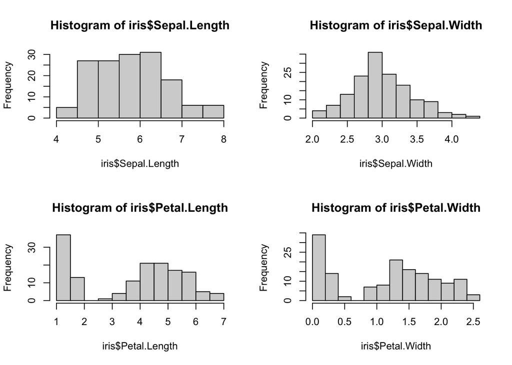

```r
par(mfrow = c(2,2))
hist(iris$Sepal.Length)
hist(iris$Sepal.Width)
hist(iris$Petal.Length)
hist(iris$Petal.Width)
```

The IVs seem to all be normally distributed except for Petal length and width. This means that these might be very useful for classification as perhaps one flower-species has a very short petal length and width compared to the other two species.

### 9) Fitting a Linear Discriminant Analysis with all or only Sepal

```r
lda_iris <- lda(Species ~ ., data = iris)

lda_iris_sepal <- lda(Species ~ Sepal.Length + Sepal.Width, data = iris)
```

### 10) Confusion matrices

```r
table(true = iris$Species, pred = predict(lda_iris, type = "response")$class)
```

```
##             pred
## true         setosa versicolor virginica
##   setosa         50          0         0
##   versicolor      0         48         2
##   virginica       0          1        49
```

```r
table(true = iris$Species, pred = predict(lda_iris_sepal, type = "response")$class)
```

```
##             pred
## true         setosa versicolor virginica
##   setosa         49          1         0
##   versicolor      0         36        14
##   virginica       0         15        35
```

Comparing the two matrices, we find that lda_iris is much much better in terms of accuracy as it only predicted it wrong three times vs. 30 times. Accuracy of lda_iris: 0.98. Accuracy of lda_iris_sepal: 0.8.

## Classification trees

### 11) Creating a classification tree

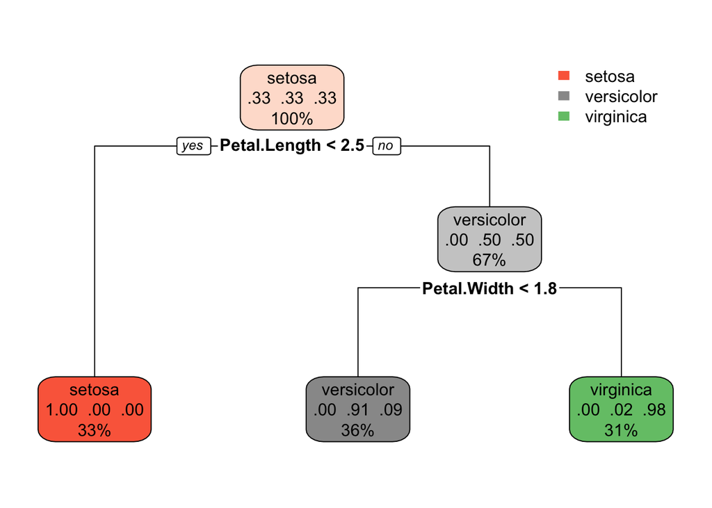

```r
iris_tree_model <- rpart(Species ~ ., data = iris)

rpart.plot(iris_tree_model)
```

### 12) How would an iris with 2.7 cm long and 1.5 cm wide petals be classified?

From the above plot we can see that if petal length is longer than 2.5 and petal width is shorter than 1.8, the plant would be classified as a *Versicolor*.

### 13) Scatterplot

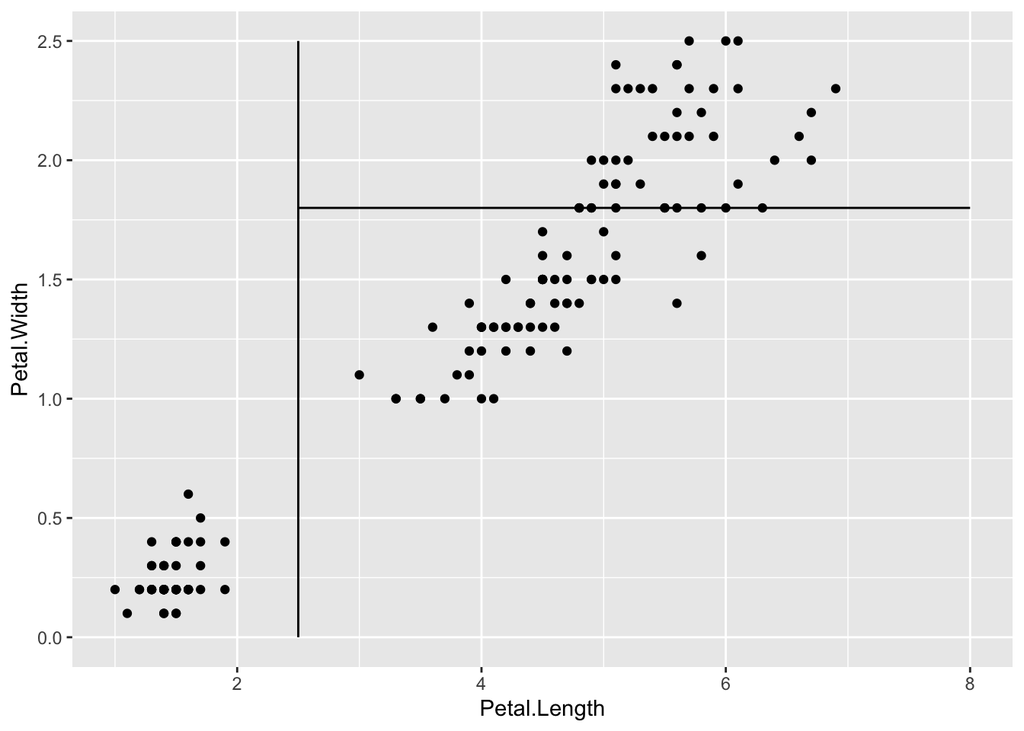

```r
ggplot(data = iris, aes(x = Petal.Length, y = Petal.Width)) +
  geom_point() +
  geom_segment(aes(x = x1, y = y1, xend = x2, yend = y2),
               data = data.frame(x1 = 2.5, y1 = 1.8, x2 = 8, y2 = 1.8)) +
  geom_segment(aes(x = x1, y = y1, xend = x2, yend = y2),
               data = data.frame(x1 = 2.5, x2 = 2.5, y1 = 0, y2 = 2.5))
```

How you can interpret this plot: everything to the left side of the vertical line is classified as a ‘Setose’. Then, on the right side of the vertical line, classification depends on the horizontal line. If observations are *above* the horizontal line, they are classified as virginica. If they are *below* the horizontal line, they are classified as versicolor.

### 14) Full classificaiton model

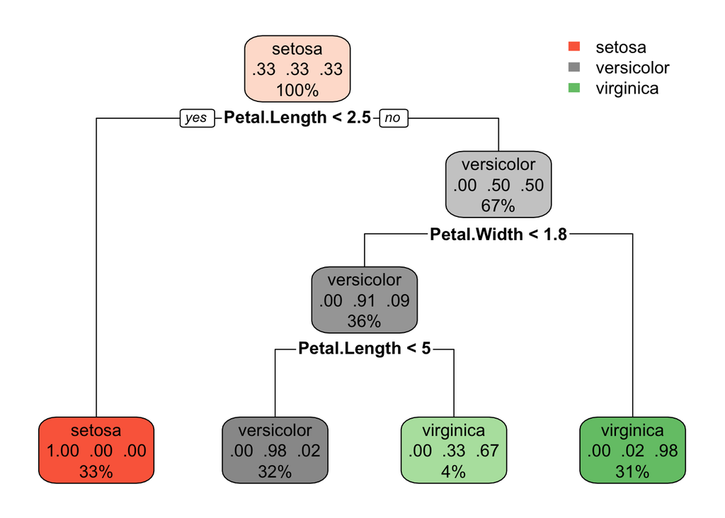

```r
iris_tree_full_mod <- rpart(Species ~ ., data = iris, minbucket = 1,
                            minsplit = 1)

rpart.plot(iris_tree_full_mod)
```

## Random forests

### 15) Final assignment

```r
rForest_mod <- randomForest(Species ~ ., data = iris, ntree = 1000,
                            replace = TRUE)

rForest_mod
```

```
##
## Call:
##  randomForest(formula = Species ~ ., data = iris, ntree = 1000,      replace = TRUE)
##                Type of random forest: classification
##                      Number of trees: 1000
## No. of variables tried at each split: 2
##
##         OOB estimate of  error rate: 4%
## Confusion matrix:
##            setosa versicolor virginica class.error
## setosa         50          0         0        0.00
## versicolor      0         47         3        0.06
## virginica       0          3        47        0.06
```

```r
importance(rForest_mod)
```

```
##              MeanDecreaseGini
## Sepal.Length         9.449998
## Sepal.Width          2.260817
## Petal.Length        42.658096
## Petal.Width         44.871863
```

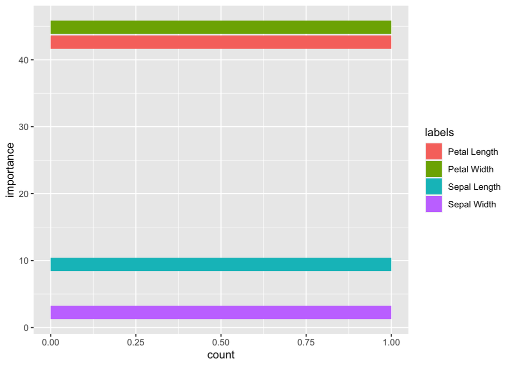

```r
ggplot(data = data.frame(labels = as.factor(c("Sepal Length", "Sepal Width",
                                    "Petal Length", "Petal Width")),
                                    importance  = importance(rForest_mod)[, 1]),
       aes(x = importance, fill = labels)) +
  geom_bar() + coord_flip()
```

Looking at the confusion matrix, we find that the random forest method was a bit worse than the lda. However, I would trust a random forest more in another dataset due to more cross validation and also it has less stringent assumptions. Furthermore, looking at the importance bar graph, we find that as expected, petal length and width are most important in classifying the different types of flowers.